# Analisando componentes principais da variação quantitativa de pessoas em situação de rua no Distrito Federal no ano 2023

Hernany Gomes de Castro | Doutorando - PPGSOL/UnB e Bruna Guimarães | Aluna especial - IPol/UnB

Agosto de 2024

## 1 Introdução

A pesquisa discute a variação quantitativa de pessoas em situação de rua no Distrito Federal no ano 2023. O trabalho consiste em mapear possíveis efeitos das políticas públicas sobre a variação quantitativa de pessoas em situação de rua nas regiões administrativas. Para alcançar esse objetivo foram utilizados dados oficiais do Governo do Distrito Federal obtidos mediante lei de acesso à informação. Com isso, foi possível analisar a variação quantitativa de pessoas em situação de rua, aferida pelo Serviço Especializado em Abordagem Social (SEAS), como as variações quantitativas das ações da assistência social, da polícia e do serviço de limpeza urbana, entre outras[^1]. Investigou-se as variações em suas direções, com o objetivo de identificar padrões que ajudem a explicar o fenômeno.

A presente Nota Técnica atende a um dos requisitos da disciplina Metodologia Quantitativa em Ciência Política, oferecida pelo Programa de Pós-graduação do Instituto de Ciência Política, da Universidade de Brasília (iPol/UnB). A participação na disciplina é o cumprimento parcial do requisito optativo do curso de doutorado do Programa de Pó-graduação em Sociologia - PPGSol/UnB. O trabalho apresentando está relacionado à pesquisa sobre a situação de rua (em andamento).

A literatura informa sobre a indisponibilidade de teorias que expliquem o trânsito de pessoas em situação de rua. Parte disso está relacionado às dificuldades administrativas na produção de registros que possam gerar dados para subsidiar essas análises, como também se deve ao fato de que a situação de rua tem sido definida a partir de uma dimensão exclusivamente temporal. Embora o trânsito entre espaços seja uma das características mais marcantes da situação de rua, não há teorias específicas que o expliquem (Lee et al, 2010). Pessoas em situação de rua podem, vez ou outra, residir em imóvel alugado, passar um tempo em abrigos, morar de favor ou ocupar imóveis cedidos quando exercendo atividades laborais. As transições entre diferentes situações de endereço são frequentes, além de ser uma maneira para “dar um tempo” da rua (Shlay e Rossi, 1992). No Brasil, Vieira et al (2004) calcula que São Paulo teria aproximadamente 4 milhões de pessoas em situação de rua em 1991, se a definição oficial levasse em conta a dimensão espacial. Por outro lado, Stofells (1977) descreve a ação estatal ostensiva na década de 1970, em São Paulo, para recolher compulsoriamente pessoas em situação de rua. E, mais recentemente, Castro (2023) mostra que a situação de endereço das pessoas em situação de rua é utilizada como critério de distribuição diferencial de atendimento pelas políticas públicas de saúde e de assistência social no Distrito Federal. Espaço e tempo estão vinculados na situação de rua como dimensões de um mesmo fenômeno. A presente pesquisa é um esforço que contribui para compreender a situação de rua a partir de uma dimensão espacial, em complemento à temporalidade.

As questões ligadas à situação de rua ganharam relevância social, recentemente, com a decisão liminar do Ministro do STF, Alexandre de Moraes, no âmbito da Arguição de Descumprimento de Preceito Fundamental - [ADPF nº 976](https://portal.stf.jus.br/noticias/verNoticiaDetalhe.asp?idConteudo=512659&ori=1), a qual foi confirmada pelo plenário do STF em 21/08/2023. A ADPF se refere as ações de zeladoria pela administração pública, sem observância das diretrizes da Política Nacional para a População em Situação de Rua (Decreto nº 7.053/2009). A decisão determinou a elaboração de um plano de ação e monitoramento pelos Estados, Municípios e o Distrito Federal, para a efeitva implantação da política nacional.

## 2 Metodologia

O estudo analisou as variações quantitativas das ações selecionadas com base no método de Análise de Componentes Principais (PCA). A PCA descreve as variações quantitativas correlacionadas em dimensões. O teste extrai informações importantes de múltiplas variáveis expressando-as em poucos componentes principais. A combinação para formar um componente principal é realizada a partir da relação linear entre as variáveis originais. Com isso, os componentes principais identificados são em menor número ou iguais a quantidade de variáveis originais. Esses componentes expressam a variação total do conjunto, mapeando a contribuição de cada variável individualmente e identificando as direções. A redução da dimensionalidade das variáveis permite uma melhor visualização gráfica das direções, com perda mínima de informação.

A realização da PCA depende de um conjunto de dados composto por variáveis numéricas sem dados ausentes. A PCA é robusta e flexvível o suficiente para lidar com um número mínimo de observações e eventual colinearidade entre as variáveis. Por outro lado, a PCA é sensível à normalidade dos dados.

A escolha da PCA justifica-se em razão da necessidade de reduzir a dimensionalidade do conjunto de dados, com perda mínima de informações. A PCA é um método adequado para explorar um conjunto de dados com muitas variáveis sem lastro teórico que indique parâmetros mínimos. A ausência de referências na literatura para análise da variação quantitativa de pessoas em situação de rua, como as dificuldades para obter os dados sobre essa variação junto ao Governo do Distrito Federal, estabelecem um limite exploratório para o estudo. As variáveis presentes no conjunto de dados são apenas uma parte daquelas que estão disponíveis no GDF, como oferecem pouca margem de transformação. A PCA responde satisfatoriamente à exploração dessas variáveis, com flexibilidade e robustez.

A PCA foi realizada em linguagem R, no software RStudio, a partir de pacotes nativos, como dos pacotes FactoMineR e factoextra.

### 2.1 Preparação dos dados

| Item | KMO |
| --- | --- |
| centropop_razao | 0.78 |
| creas_razao | 0.88 |
| refeicao_razao | 0.84 |
| abordagem_razao | 0.85 |
| cadunico_razao | 0.67 |
| aux_vul_razao | 0.86 |
| residuos_razao | 0.74 |
| seletiva_razao | 0.77 |
| ouvidoria_razao | 0.77 |
| ocorrencias_razao | 0.85 |
| drogas_razao | 0.77 |
| mean_ativos_razao | 0.86 |

A seguir, detalha-se cada uma das variáveis utilizadas.

| grupo_renda | centropop_razao | creas_razao | refeicao_razao | abordagem_razao | cadunico_razao | aux_vul_razao | residuos_razao | seletiva_razao | ouvidoria_razao | ocorrencias_razao | drogas_razao | mean_ativos_razao |
| --- | --- | --- | --- | --- | --- | --- | --- | --- | --- | --- | --- | --- |
| g1_alta_renda | 0.56619 | 0.00151 | -0.5164419 | 0.94210683 | 2.727880088 | -0.152118540 | -0.63264859 | -0.67165532 | 0.06547680 | 1.41769289 | -0.35293385 | 1.434962323 |
| g1_alta_renda | 0.57021 | 0.00151 | -0.5243239 | 1.25274578 | -0.506338799 | -0.405850886 | -0.62249134 | -0.64977352 | 0.12414477 | 1.37277329 | -0.32051741 | 1.389521262 |
| g1_alta_renda | 4.31718 | 0.01143 | 0.5589534 | -0.10629698 | -0.792239610 | 0.376595545 | 0.94372153 | 1.64106407 | 0.97540541 | -0.03911123 | 0.08686702 | -0.204525663 |
| g1_alta_renda | 0.70912 | 0.00201 | -0.5285210 | 0.90996809 | 2.398958012 | -0.479306124 | -0.63530757 | -0.69146993 | 0.18166238 | 1.68368735 | 0.18598627 | 0.589365764 |
| g1_alta_renda | 0.87973 | 0.00101 | -0.5874085 | 1.31487357 | 3.357951017 | -0.280101357 | -0.60277238 | -0.66628638 | 0.81895751 | 1.41769289 | -0.33125579 | 0.618748506 |
| g1_alta_renda | 4.18402 | 0.00479 | -0.2051616 | -0.75811732 | -0.869568972 | 0.639460045 | 0.26499141 | 0.47034073 | -0.33944718 | -0.71026283 | -0.13872969 | -0.724098537 |
| g1_alta_renda | 0.59236 | 0.00302 | -0.5118891 | 1.36414587 | 2.070035936 | -0.394728675 | -0.63826431 | -0.68011683 | 0.18166238 | 1.46173170 | -0.36357160 | 0.577341932 |
| g1_alta_renda | 0.53750 | 0.00302 | -0.5148768 | 1.27309322 | 2.206723753 | -0.341306684 | -0.64006169 | -0.66814439 | 0.29784795 | 1.19573724 | -0.36326766 | 0.641469036 |
| g1_alta_renda | 0.57776 | 0.00101 | -0.5057144 | 1.28060645 | -0.588569318 | -0.430328595 | -0.62362936 | -0.64853485 | 0.81895751 | 1.41769289 | -0.22863827 | -0.473960363 |
| g1_alta_renda | 2.74786 | 0.00479 | 0.1833776 | -0.33016135 | -0.869568972 | -0.075036975 | 0.16579516 | 0.55477124 | -0.33944718 | -0.49975727 | 0.34932247 | -0.673269314 |

[output cut: 136 more lines]

### 2.2 Análise de componentes principais (PCA)

[output not shown]

### 2.3 Seleção dos componentes principais

A tabela, a seguir, mostra os autovalores e o percentual acumulado de explicação da variação total para as 12 dimensões identificadas. Nota-se que Dim1, Dim2 e Dim3 se destacam, apresentando autovalor de 6.94, 1.54 e 1.10, respectivamente, além de poder explicativo de 80.02% sobre a variação total. Embora Dim3 atenda ao critério de autovalor acima de 1.00, a análise será realizada com base em Dim1 e Dim2. Considera-se que Dim1 e Dim2 oferecem uma redução satisfatória da dimensionalidade das variáveis originais com baixa perda de informação.

```
##         eigenvalue variance.percent cumulative.variance.percent
## Dim.1  6.945623243      57.88019369                    57.88019
## Dim.2  1.548345746      12.90288122                    70.78307
## Dim.3  1.109166824       9.24305686                    80.02613
## Dim.4  0.732026339       6.10021949                    86.12635
## Dim.5  0.536560251       4.47133543                    90.59769
## Dim.6  0.364989505       3.04157921                    93.63927
## Dim.7  0.288289819       2.40241516                    96.04168
## Dim.8  0.252228274       2.10190229                    98.14358
## Dim.9  0.145656255       1.21380213                    99.35739
## Dim.10 0.040062979       0.33385816                    99.69124
## Dim.11 0.033849279       0.28207733                    99.97332
## Dim.12 0.003201486       0.02667905                   100.00000
```

A qualidade da representação das variáveis originais no mapa fatorial é mostrada no gráfico a seguir (em porcentagem). O gráfico mostra que Dim1 concentra a representatividade mais relevante das variáveis originais.

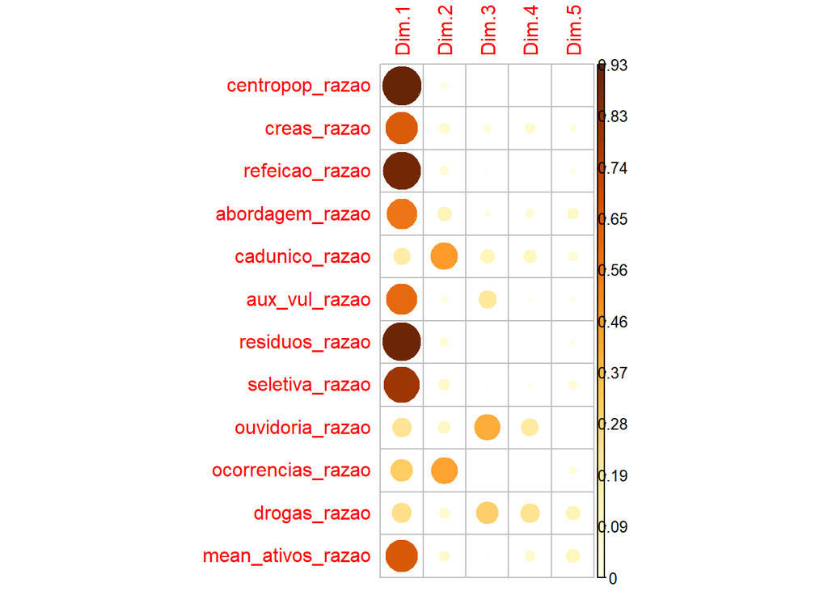

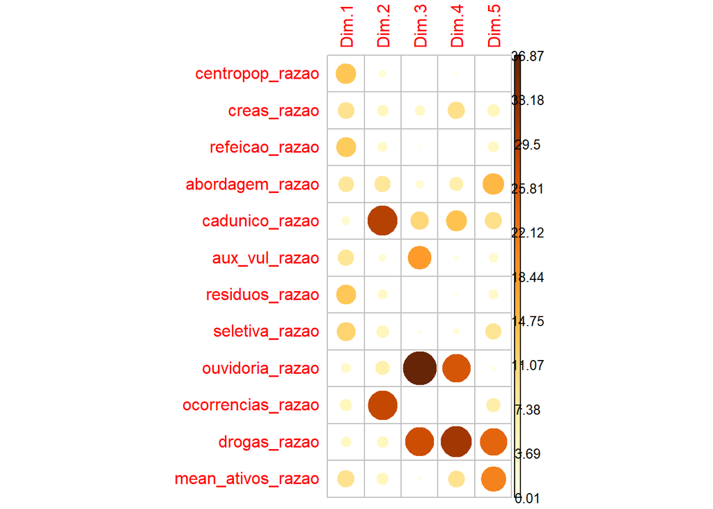

A contribuição de cada uma das variáveis originais para Dim1 pode ser vista no gráfico a seguir. Nota-se a expressiva quantidade de variáveis e os respectivos percentuais de contribuição.Das 10 variáveis identificadas, 07 estão com valores acima da média. Dim1 é o principal componente identificado na PCA.

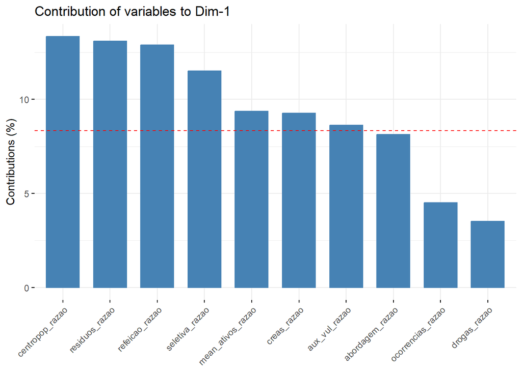

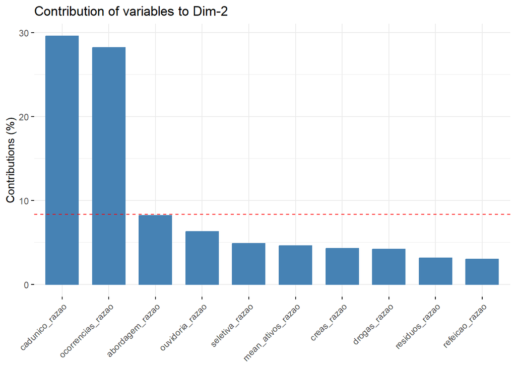

Além disso, identificou-se forte correlação entre as variáveis nas três primeiras dimensões, com p-valor significativo. A tabela, a seguir, mostra esses valores e, ainda, que parte das correlações em Dim2 é negativa. Ou seja, para 07 das 12 variáveis originais a correlação em Dim2 é negativa.

```
## $Dim.1
##
## Link between the variable and the continuous variables (R-square)
## =================================================================================
##                   correlation      p.value
## centropop_razao     0.9626812 1.265421e-83
## residuos_razao      0.9538559 4.007197e-77
## refeicao_razao      0.9465426 1.227730e-72
## seletiva_razao      0.8943285 3.728426e-52
## mean_ativos_razao   0.8064997 1.114871e-34
## creas_razao         0.8023845 4.326324e-34
## aux_vul_razao       0.7743668 2.028794e-30
## abordagem_razao     0.7511806 9.278547e-28
## ocorrencias_razao   0.5595404 2.112848e-13
## drogas_razao        0.4945955 2.221897e-10
## ouvidoria_razao     0.4737250 1.548963e-09
## cadunico_razao      0.4158802 1.785908e-07
##
## $Dim.2
##
## Link between the variable and the continuous variables (R-square)
## =================================================================================
##                   correlation      p.value
## cadunico_razao      0.6766968 6.931153e-21
## ocorrencias_razao   0.6610299 1.088496e-19
## abordagem_razao     0.3568513 9.813492e-06
## ouvidoria_razao     0.3116104 1.288675e-04
## mean_ativos_razao   0.2671030 1.117671e-03
## centropop_razao    -0.1650280 4.652802e-02
## aux_vul_razao      -0.1694313 4.090865e-02
## refeicao_razao     -0.2157709 8.905880e-03
## residuos_razao     -0.2196870 7.714856e-03
## drogas_razao       -0.2552634 1.873861e-03
## creas_razao        -0.2572055 1.724337e-03
## seletiva_razao     -0.2749619 7.828116e-04
##
## $Dim.3
##
## Link between the variable and the continuous variables (R-square)
## =================================================================================
##                 correlation      p.value
## ouvidoria_razao   0.6394835 3.711032e-18
## drogas_razao      0.5502847 6.251053e-13
## creas_razao      -0.1966454 1.736308e-02
## cadunico_razao   -0.3478043 1.696548e-05
## aux_vul_razao    -0.4490948 1.303453e-08
```

## 3 Resultados

```
##                       Dim.1      Dim.2        Dim.3        Dim.4        Dim.5
## centropop_razao   0.9267552 0.02723425 0.0001957048 2.232981e-03 0.0005448955
## creas_razao       0.6438209 0.06615466 0.0386694085 7.096063e-02 0.0264179060
## refeicao_razao    0.8959428 0.04655710 0.0039955822 7.669142e-04 0.0199794462
## abordagem_razao   0.5642724 0.12734283 0.0229684736 4.674343e-02 0.0804483950
## cadunico_razao    0.1729563 0.45791853 0.1209678182 1.025290e-01 0.0515832149
## aux_vul_razao     0.5996439 0.02870696 0.2016861423 5.072280e-03 0.0146269261
## residuos_razao    0.9098411 0.04826237 0.0001364083 2.840229e-03 0.0163087645
## seletiva_razao    0.7998234 0.07560407 0.0036743228 9.710557e-03 0.0467175894
## ouvidoria_razao   0.2244153 0.09710103 0.4089391397 1.922587e-01 0.0023470673
## ocorrencias_razao 0.3130854 0.43696054 0.0002819346 5.267314e-05 0.0354833393
## drogas_razao      0.2446247 0.06515939 0.3028132497 2.306272e-01 0.1299854175
## mean_ativos_razao 0.6504417 0.07134401 0.0048386392 6.823174e-02 0.1121172893
```

### 3.1 Autovalores e variância explicada

Dois componentes foram selecionados para prosseguimento da análise. Com 70.78% da variação total explicada por Dim1 e Dim2 é posível reduzir a dimensionalidade das variáveis originais, com comprometimento mínimo de informações. Relembrando, os autovalores de Dim1 e Dim2 são, respectivamente, 6.94 e 1.54, conforme discutido na seção 2.3. As dimensões escolhidas para análise abordam as desigualdades sociais em relação à situação de rua no Distrito Federal, sob perspectivas complementares, embora diferentes.

O cruzamento entre Dim1 e Dim2 representa o ponto de indiferença entre a vulnerabilidade social, a segurança pública e as demandas por inclusão social em relação à situação de rua. O gráfico, a seguir, mostra a correlação entre as variáveis e os componentes Dim1 e Dim2.

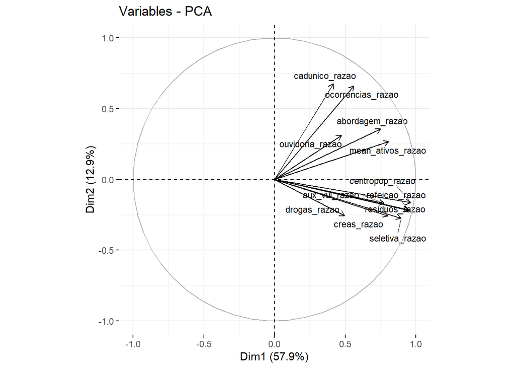

A seguir, discute-se cada uma das dimensões do gráfico.

#### 3.1.1 Rejeição como Dimensão da Situação de Rua

A análise de uma amostra[^3] dos registros de ouvidorias do sistema do Governo do Distrito Federal corrobora a compreensão de Dim1 enquanto dimensão que expressa um sentimento de rejeição da população em relação à situação de rua. A análise, realizada com apoio do software requalify[^4] de Inteligência Artificial (Martins et al, 2024), identificou cinco tags que remetem a um sentido da situação de rua associada como ameaça ao patrimônio, à vida, à saúde e à segurança pública. A situação de rua é vinculada nas ouvidorias à presença de drogas, ao crime, à sujeira e à desordem. As ouvidorias propõem a retirada compulsória das pessoas em situação de rua das áreas públicas, com o objetivo de garantir a segurança e a qualidade de vida das comunidades afetadas.

Entrevistas realizadas por Castro (2023) mostram que é possível encontrar pessoas em situação de rua que não reconhecem sua condição. Lee et al (2010) identificam que pessoas em situação de rua possuem um extenso repertório para gerenciamento de identidade, inclusive negando sua condição na presença de pessoas domiciliadas. As entrevistas realizadas por Castro (2023) mostram que a identificação como trabalhador é um forma utilizada para distinção em relação ao estigma da situação de rua.

#### 3.1.2 Intolerância como Dimensão da Situação de Rua

Dim2 é uma dimensão que combina variáveis relativas à vulnerabilidade social com demandas por serviços públicos. Dim2 relativiza o sentimento de rejeição da população aferido em Dim1, captando a variação da intolerância quando pessoas em situação de rua são alcançadas pelas políticas públicas. Em outras palavras, Dim2 afere a variação do sentimento de rejeição sobre a situação de rua em relação às políticas públicas. Quanto mais os valores de Dim2 escalam a parte superior do gráfico, maior a intolerância.

Em três das cinco tags identificadas na análise dos registros de ouvidorias, a demanda por serviços públicos está presente. As ouvidorias mostram que a população reconhece a responsabilidade e a ausência do Estado em relação à situação de rua. Por um lado, como forma de assegurar o próprio bem-estar. Por outro, enquanto possibilidade de inclusão social das pessoas em situação de rua. A rejeição da população em relação à situação de rua pode ser atenuada com políticas públicas.

As entrevistas realizadas por Castro (2023) mostram que o acesso às políticas públicas é um reconhecimento social de cidadania para as pessoas em situação de rua. As políticas públicas facilitam o gerenciamento da identidade pelas pessoas em situação de rua na presença de domiciliados.

### 3.2 Carregamentos dos componentes

O plano social teórico foi carregado com observações de variação associadas aos grupos de região administrativa por renda da população (IPEDF-DIESSE, 2023). Os grupos de renda compreendem uma metodologia desenvolvida pelo Instituto de Pesquisa e Estatística do Distrito Federal (IPEDF), em parceria com o Departamento Intersindical de Estatística e Estudos Socioecômicos (DIEESE), para analisar o mercado de trabalho local a partir da dimensão territorial. Os grupos de renda organizam as regiões administrativas, conforme a seguir:

| Grupo | Regiao |
| --- | --- |
| Alta Renda | Jardim Botânico |
| Alta Renda | Lago Norte |
| Alta Renda | Lago Sul |
| Alta Renda | Park Way |
| Alta Renda | Plano Piloto |
| Alta Renda | Sudoeste/Octogonal |
| Média-Alta Renda | Águas Claras |
| Média-Alta Renda | Candangolândia |
| Média-Alta Renda | Cruzeiro |
| Média-Alta Renda | Gama |
| Média-Alta Renda | Guará |
| Média-Alta Renda | Núcleo Bandeirante |
| Média-Alta Renda | Sobradinho |
| Média-Alta Renda | Sobradinho II |
| Média-Alta Renda | Taguatinga |
| Média-Alta Renda | Vicente Pires |
| Média-Baixa Renda | Brazlândia |
| Média-Baixa Renda | Ceilândia |
| Média-Baixa Renda | Planaltina |
| Média-Baixa Renda | Riacho Fundo |
| Média-Baixa Renda | Riacho Fundo II |
| Média-Baixa Renda | SIA |
| Média-Baixa Renda | Samambaia |
| Média-Baixa Renda | Santa Maria |
| Média-Baixa Renda | São Sebastião |
| Baixa Renda | Fercal |
| Baixa Renda | Itapoã |
| Baixa Renda | Paranoá |
| Baixa Renda | Recanto das Emas |
| Baixa Renda | SCIA/Estrutural |
| Baixa Renda | Varjão |

Os gráficos, a seguir, mostram a distribuição dos grupos de renda no plano social teórico.

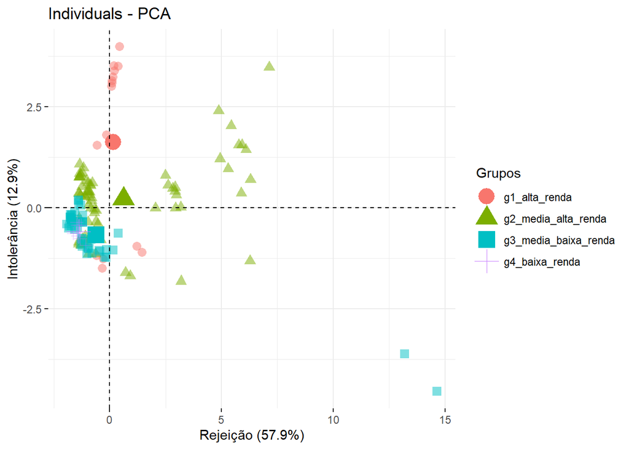

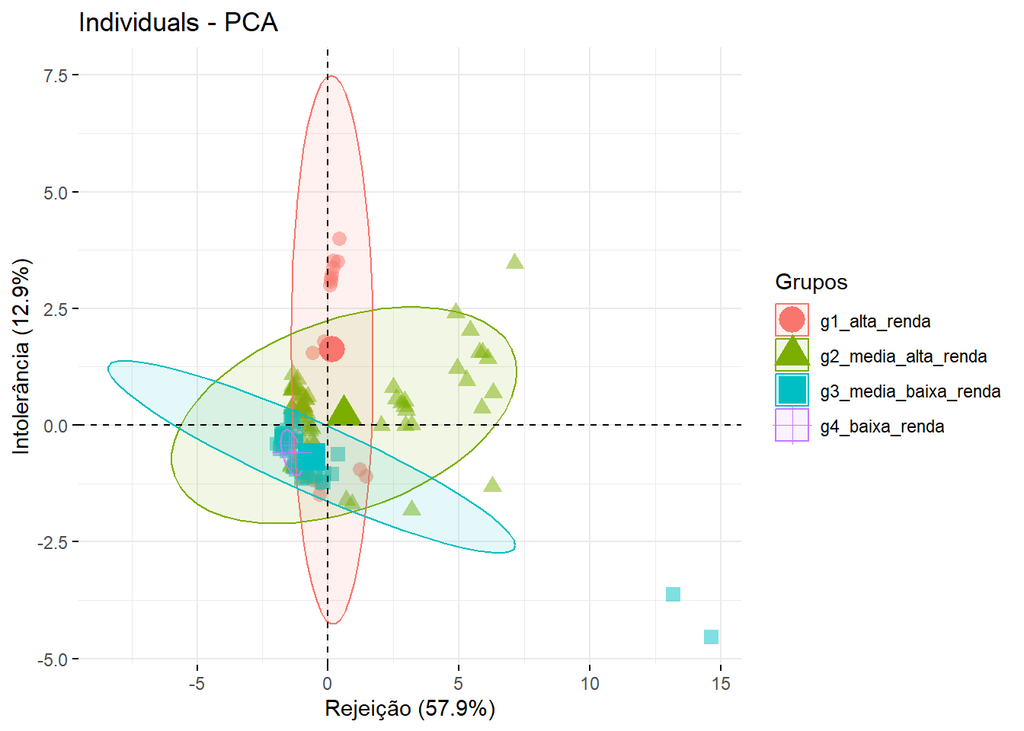

## 4 Discussão

A utilização da Análise de Componentes Principais (PCA) possibilitou criar um plano social teórico do trânsito das pessoas em situação de rua nas regiões administrativas, considerando dois eixos: rejeição (x) e intolerância (y). O plano é constituído a partir de duas dimensões principais identificadas pela PCA, com base nas variáveis originais. Essas dimensões explicam 70.78% da variação total do conjunto de dados analisado. As dimensões aferem a variação do sentimento da população em relação à situação de rua, considerando a presença das políticas públicas. A primeira dimensão se refere ao sentimento de insegurança da população em relação à situação de rua, sendo denominada “Rejeição”. A segunda dimensão diz respeito ao efeito que as políticas públicas geram sobre esse sentimento de rejeição, sendo por isso denominada “Intolerância”. O plano social teórico criado permitiu mapear a posição das regiões administrativas em relação à variação quantitativa das pessoas em situação de rua por grupos de renda.

### 4.1 Interpretação dos componentes

A posição das RA’s no plano social teórico do trânsito da situação de rua difere segundo a renda da população. RA’s de renda alta e média alta concentram uma população menos tolerante e mais refratária à situação de rua do que as RA’s com renda baixa e média baixa. A população das RA’s do grupo de média alta renda se mostra menos tolerante e mais avessa à presença de pessoas em situação de rua do que a das RA’s de baixa renda. Por outro lado, a população das RA’s de renda alta são menos tolerantes e mais refratárias do que a população das RA’s de renda média baixa. A renda da população se mostrou uma variável influente sobre a variação quantitativa das pessoas em situação de rua nas regiões administrativas do Distrito Federal.

### 4.2 Limitações da análise

A PCA se restringiu à exploração das variações quantitativas do conjunto de dados em relação à direção das variáveis originais. Os componentes principais identificados estão sujeito a alterações devido a introdução de novas variáveis, o que pode ou não modificar as direções. A pesquisa se restringiu ao uso dos dados que foram disponibilizados pelo Governo do Distrito Federal. É importante registrar, contudo, que nem todos os dados solicitados desde janeiro/2024 foram disponibilizados até a elaboração da presente Nota Técnica. A presente análise não autoriza extrapolar as inferências realizadas considerando variáveis ausentes do modelo.

O plano social teórico proposto explica parte da variação dos dados analisados. Os componentes principais identificados explicam até 70.78% da variação total. Portanto, há uma margem de variação não explicada pelo modelo da ordem de 29,22%. O plano social teórico do trânsito da situação de rua nos grupos de renda das regiões administrativas tem poder explicativo limitado.

O modelo leva em consideração a política institucional vigente em 2023 que orientou as políticas públicas. Alterações na metodologia das políticas públicas podem levar a resultados diferentes em anos diferentes, embora com as mesmas variáveis originais. Modificações na forma de atuação, no registro administrativo dos dados, como no tamanho das equipes ou nos desenhos de territorialização, por exemplo, podem gerar alterações nas variações em análise. Mudanças nas políticas públicas podem inviabilizar a comparabilidade entre as variações dos dados para anos diferentes.

## 5 Conclusões

A pesquisa analisou a variação quantitativa de pessoas em situação de rua nas regiões administrativas do Distrito Federal no ano 2023, como de diferentes ações das políticas públicas, à exemplo da assistência social e de resíduos sólidos, além da ação policial. O objetivo foi identificar os possíveis efeitos das políticas públicas sobre a variação quantitativa de pessoas em situação de rua nas regiões administrativas, mapeando o efeito de cada uma das ações em particular.

Os dois principais componentes identificados na PCA sugerem que as variações quantitativas das políticas públicas em relação a pessoas em situação de rua é sensível à renda da população. O plano social teórico do trânsito da situação de rua pode explicar até 70.78% da variação total identificada para o ano 2023. A análise realizada permite inferir que o sentimento de insegurança da população em relação à situação de rua é sensível a presença de políticas públicas. O caso das RA’s de média alta renda sugere, ainda, que essa presença está relacionada a volume e qualidade. Em outras palavras, a variação quantiativa de pessoas em situação de rua nas RA’s está relacionada à combinação entre renda da população, presença, volume e qualidade das políticas públicas.

## 6 Referências bibliográficas

ABDI, Hervé, e Lynne J. Williams. 2010. “Principal Component Analysis.” John Wiley and Sons, Inc. WIREs Comp Stat 2: 433–59.

BRASIL, R. F. DO. Decreto no 7.053. Política Nacional para a População em Situação de Rua - PNPR. . 23 dez. 2009.

CASTRO, H. Vínculos de (Sub)Cidadania: um estudo de caso sobre os laços sociais de pessoas em situação de rua com as políticas públicas de Saúde e de Assistência Social em São Sebastião-DF. [Dissertação de Mestrado]. Brasília, DF: PPGSOL - Universidade de Brasília, 2023.

IPEDF-DIEESE. **Boletim-Especial-Anual-03-Trabalho-e-Territorio-FINAL.pdf**. Brasília: IPEDF-DIEESE, 2023. Disponível em: <[https://www.ipe.df.gov.br/wp-content/uploads/2024/05/Boletim-Especial-Anual-03-Trabalho-e-Territorio-FINAL.pdf\\](https://www.ipe.df.gov.br/wp-content/uploads/2024/05/Boletim-Especial-Anual-03-Trabalho-e-Territorio-FINAL.pdf/)>. Acesso em: 2 ago. 2024.

LEE, B. A.; TYLER, K. A.; WRIGHT, J. D. The New Homelessness Revisited. Annual Review of Sociology, v. 36, n. 1, p. 501–521, 1 jun. 2010.

MARTINS, L. F; Souza, F. R.; Freitas, J. M. (2024). requalify.ai (Version 0.1)[online software]. https://requalify.ai

MORAES, A. DE. DECISÃO ADPF 976 MC/DFSuperior Tribunal Federal - STF, , 25 jul. 2003. Disponível em: https://www.stf.jus.br/arquivo/cms/noticiaNoticiaStf/anexo/ADPF976MC1.pdf. Acesso em: 10 ago. 2023

SHLAY, A. B.; ROSSI, P. H. Social Science Research and Contemporary Studies of Homelessness. Annual Review of Sociology, 1992.

STHDA. **PCA in R Using FactoMineR: Quick Scripts and Videos - Articles - STHDA**. Disponível em: <[http://www.sthda.com/english/articles/22-principal-component-methods-videos/65-pca-in-r-using-factominer-quick-scripts-and-videos/\\](http://www.sthda.com/english/articles/22-principal-component-methods-videos/65-pca-in-r-using-factominer-quick-scripts-and-videos/)>. Acesso em: 2 ago. 2024.

STOFFELS, M.-G. Os Mendigos na Cidade de São Paulo: ensaio de interpretação sociológica. Rio de Janeiro: Paz e Terra, 1977.

VIEIRA, M. A. DA C.; BEZERRA, E. M. R.; ROSA, C. M. MA. (EDS.). População de Rua: quem é, como vive, como é vista. 3o ed. São Paulo: HUCITEC, 2004.

[^1]: Embora a pesquisa tenha reunido dados de ações da política pública de saúde, como Consultório na Rua e Unidade de Pronto-atendimento, essas variáveis foram excluídas da análise devido a alta quantidade de missings.
[^2]: Valores de KMO acima de 0.7 são considerados adequados para análise fatorial.
[^3]: n = 44.
[^4]: Requalify.ai é um software inteligência artificial (IA) que utiliza Large Language Models (LLMs) com arquitetura Generative Pre-trained Transformer (GPT) para apoiar a análise de dados qualitativos. O software combina técnicas avançadas de processamento de linguagem natural (PLN) em uma plataforma interativa, que permite analisar dados qualitativos utilizando técnicas clássicas com apoio de IA.